# TA - Assignment 1 - Task 1

Vaibhav Pralhad Mhaske, CBA Batch 7 - Section B, 71620083

## Task 1 - Text-Analyzing a simple set of documents.

We collect reviews data for IMBD movie (top 250 movie) - **Schindler’s List**. We collect both the positive reviews (50) and negative reviews (50) along with the user rating given to the review. URL- http://www.imdb.com/title/tt0108052/reviews?filter=love;filter=love;start=0.

#### Reviews data collection from IMDB website for movie **Schindler’s List**.

We observe that for positive reviews the ratings given by the users is ‘10/10’ and for negative reviews the rating given by users is mostly ‘1/10’. Few users have given the ratings ‘2/10’ for negative reviews. We create the ratings vector for the reviews using these values.

```r
library("rvest")

counts = c(0,10,20,30,40)
reviews = NULL
ratings = NULL
for (j in counts){
  url1 = paste0("http://www.imdb.com/title/tt0108052/reviews?filter=love;filter=love;start=",j)
  url2 = paste0("http://www.imdb.com/title/tt0108052/reviews?filter=hate;filter=hate;start=",j)

  page1 = read_html(url1)
  page2 = read_html(url2)

  reviews1 = html_text(html_nodes(page1,'#tn15content div + p'))
  ratings1 = rep(10,length(reviews1))
  if (reviews1 != 'NULL') ratings1 = rep(10,length(reviews1))
  reviews2 = html_text(html_nodes(page2,'#tn15content div + p'))
  #ratings2 = rep(1,length(reviews2))
  if (j < 35) {
  ratings2 = rep(1,length(reviews2))
  }
  if (j == 40) {
  l = length(reviews2)
  ratings2[1:(l-2)] = 1
  ratings2[(l-1):(l)] = 2
  }

  reviews.positive = setdiff(reviews1, c("*** This review may contain spoilers ***","Add another review"))
  reviews.negative = setdiff(reviews2, c("*** This review may contain spoilers ***","Add another review"))

  reviews = c(reviews,reviews.positive,reviews.negative)
  ratings = c(ratings,ratings1,ratings2)

}

reviews = gsub("\n",' ',reviews)
writeLines(reviews,'C:/Vaibhav/ao/ta/asgnat/schindlersreviews.txt')
rev_rat = data.frame(reviews, ratings)
write.table(rev_rat,'C:/Vaibhav/ao/ta/asgnat/schindlersrevrat.txt',row.names = FALSE)
```

#### Reviews data

```r
head(rev_rat) # Reviews data
```

```
##                                                                                                                                                                                                                                                                                                          …
## 1  I know many of you, out there will disagree with me, when I say that Schindler's List is one of the greatest film that there has ever been. It does sound that I'm extremely overrating it, but I truly believe that Schindler's List is up there with The Godfather and Citizen Kane I mean everythin…
## 2                                                                                                                                                                                                                                                                                                        …
## 3                                                                                                                                                                                                                                                                                                        …
## 4                                                                                                                                                                                                                                                                                                        …
## 5                                                                                                                                                                                                                                                                                                        …
## 6                                                                                                                                                                                                                                                                                                        …
##   ratings
## 1      10
## 2      10
## 3      10
## 4      10
## 5      10
## 6      10
```

We process the reviews data to genretate **DTM (Document Term Matrix)** under tf(term frequency) and tfidf (term frequency inverse document frequency) weighting schemes. We generate World cloud, Bar plot and COG (Co-Occurence Graphs) for both positive and negative words.

```r
library(text2vec)
library(data.table)
library(stringr)
library(tm)
library(RWeka)
library(tokenizers)
library(slam)
library(wordcloud)
library(qdap)
library(ggplot2)

text.clean = function(x)                    # clean text data
{ require("tm")
  x  =  gsub("<.*?>", " ", x)               # regex for removing HTML tags
  x  =  iconv(x, "latin1", "ASCII", sub="") # Keep only ASCII characters
  x  =  gsub("[^[:alnum:]]", " ", x)        # keep only alpha numeric
  x  =  tolower(x)                          # convert to lower case characters
  x  =  removeNumbers(x)                    # removing numbers
  x  =  stripWhitespace(x)                  # removing white space
  x  =  gsub("^\\s+|\\s+$", "", x)          # remove leading and trailing white space
  return(x)
}

# Reading text data

data = read.table('C:/Vaibhav/ao/ta/asgnat/schindlersrevrat.txt',header = TRUE,stringsAsFactors = FALSE)
data$id = (1:length(data$ratings))

stpw1 = readLines('C:/Vaibhav/ao/ta/asgnat/stopwords.txt')
stpw2 = tm::stopwords('english') # tm package stop word list; tokenizer package has the same name function
comn  = unique(c(stpw1, stpw2)) # Union of two list
stopwords = unique(gsub("'"," ",comn))  # final stop word list after removing punctuation
```

#### Stopwords to be used to process reviews data

```r
stopwords # Stopwords
```

```
##   [1] "a"             "a s"           "able"          "about"
##   [5] "above"         "according"     "accordingly"   "across"
##   [9] "actually"      "after"         "afterwards"    "again"
##  [13] "against"       "ain t"         "all"           "allow"
##  [17] "allows"        "almost"        "alone"         "along"
##  [21] "already"       "also"          "although"      "always"
##  [25] "am"            "among"         "amongst"       "an"
##  [29] "and"           "another"       "any"           "anybody"
##  [33] "anyhow"        "anyone"        "anything"      "anyway"
##  [37] "anyways"       "anywhere"      "apart"         "appear"
##  [41] "appreciate"    "appropriate"   "are"           "aren t"
##  [45] "around"        "as"            "aside"         "ask"
##  [49] "asking"        "associated"    "at"            "available"
##  [53] "away"          "awfully"       "b"             "be"
##  [57] "became"        "because"       "become"        "becomes"
```

[output cut: 130 more lines]

```r
x  = text.clean(data$reviews)             # pre-process text corpus
x  =  removeWords(x,stopwords)            # removing stopwords created above
x  =  stripWhitespace(x)                  # removing white space
```

#### Create DTM

```r
tok_fun = word_tokenizer
it_m = itoken(x,
              tokenizer = tok_fun,
              ids = data$id,
              progressbar = T)

vocab = create_vocabulary(it_m)

pruned_vocab = prune_vocabulary(vocab,term_count_min = 1)

vectorizer = vocab_vectorizer(pruned_vocab)

dtm_m  = create_dtm(it_m, vectorizer)

dtm = as.DocumentTermMatrix(dtm_m, weighting = weightTf)
  a0 = (apply(dtm, 1, sum) > 0)   # build vector to identify non-empty docs
  dtm = dtm[a0,]                  # drop empty docs
```

#### DTM (Document Term Matrix)

```r
dtm
```

```
## <<DocumentTermMatrix (documents: 100, terms: 3608)>>
## Non-/sparse entries: 8577/352223
## Sparsity           : 98%
## Maximal term length: 19
## Weighting          : term frequency (tf)
```

#### Get the polarities for all the reviews. Get positive words and negative words.

```r
library(qdap)

x1 = x[a0]    # remove empty docs from corpus

pol = polarity(x1)         # Calculate the polarity from qdap dictionary
wc = pol$all[,2]           # Word Count in each doc
val = pol$all[,3]          # average polarity score
p  = pol$all[,4]           # Positive words info
n  = pol$all[,5]           # Negative Words info

positive_words = unique(setdiff(unlist(p),"-"))  # Positive words list
negative_words = unique(setdiff(unlist(n),"-"))  # Negative words list
```

#### Group polarity

```r
head(pol$group) # Group polarity
```

```
##   all total.sentences total.words ave.polarity sd.polarity
## 1 all             100       10662   -0.2209914   0.6654949
##   stan.mean.polarity
## 1         -0.3320708
```

#### Head(Positive words)

```r
head(positive_words)       # positive words found in the corpus
```

```
## [1] "greatest"   "good"       "perfection" "brilliant"  "amazing"
## [6] "incredible"
```

#### Head(Negative words)

```r
head(negative_words)       # negative words found in the corpus
```

```
## [1] "disagree"     "doubt"        "antagonist"   "travesty"
## [5] "bleak"        "hopelessness"
```

#### Create a Word Cloud and Bar plot for positive words (tf weighting)

```r
pos.tdm = dtm[,which(colnames(dtm) %in% positive_words)]
m = as.matrix(pos.tdm)
v = sort(colSums(m), decreasing = TRUE)
```

#### Word Cloud

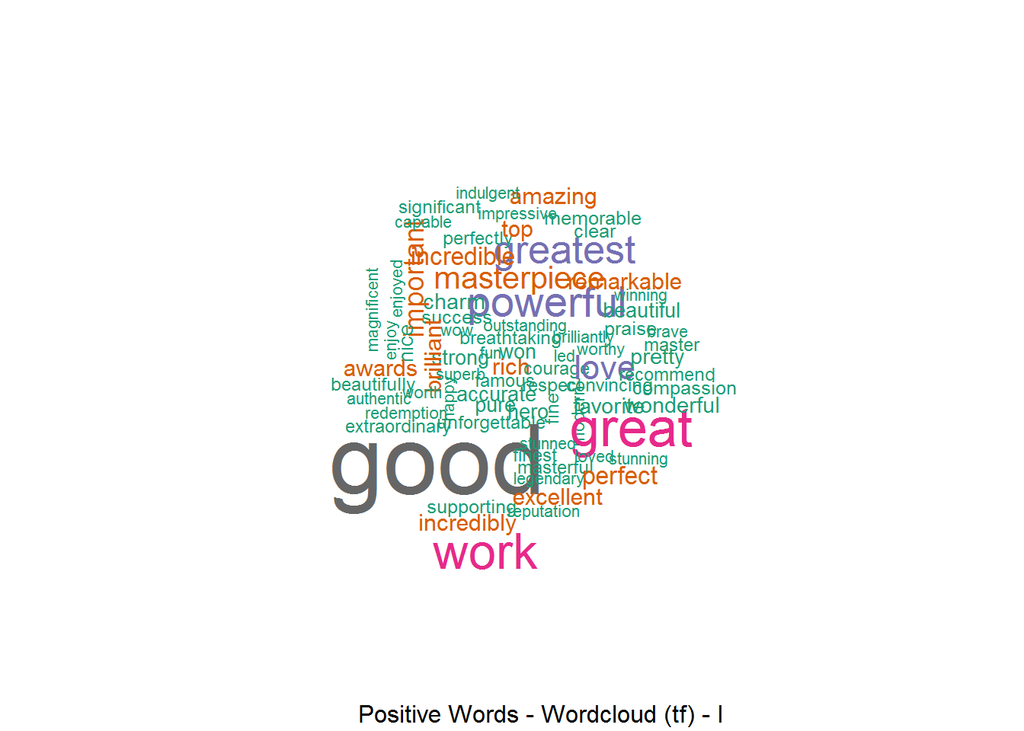

```r
windows() # opens new image window
wordcloud(names(v), v, scale=c(4,0.5),1, max.words=75,colors=brewer.pal(8, "Dark2"))
title(sub = "Positive Words - Wordcloud (tf) - I")
```

```r
test = as.data.frame(v[1:15]) # plot barchart for top tokens
```

#### Bar plot

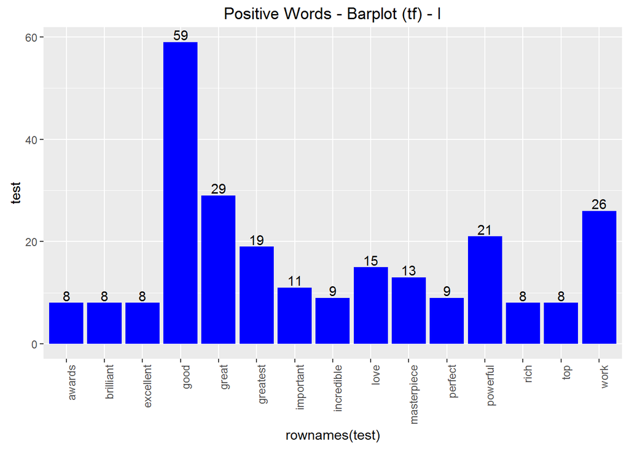

```r
windows() # opens new image window
ggplot(test, aes(x = rownames(test), y = test)) +
  geom_bar(stat = "identity", fill = "blue") +
  geom_text(aes(label = test), vjust= -0.20) +
  theme(axis.text.x = element_text(angle = 90, hjust = 1))+
  ggtitle("Positive Words - Barplot (tf) - I")
```

#### From the Bar Plot, we find words **‘good’** and **‘great’** appear frequently. We find words such as ‘love’ and ‘work’ which donot reflect positivity so we add these words to the stop words. As words ‘great’ and ‘greatest’ mean the same thing in the given context, hence we add word ‘greatest’ to the stop words.

```r
stopwords <- c(stopwords,'love','work','greatest')
```

#### Create a Word Cloud and Bar plot for negative words (tf weighting)

```r
neg.tdm = dtm[,which(colnames(dtm) %in% negative_words) ]
m = as.matrix(neg.tdm)
v = sort(colSums(m), decreasing = TRUE)
```

#### Word Cloud

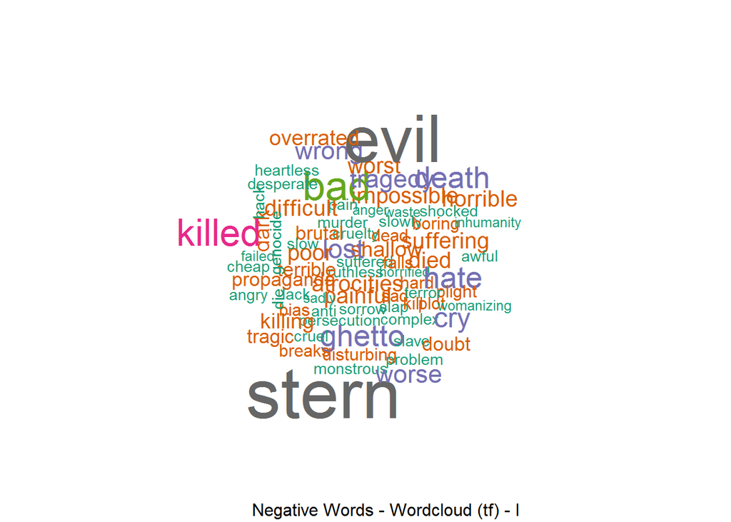

```r
windows()
wordcloud(names(v), v, scale=c(4,0.5),1, max.words=75,colors=brewer.pal(8, "Dark2"))
title(sub = "Negative Words - Wordcloud (tf) - I")
```

```r
test = as.data.frame(v[1:15]) # plot barchart for top tokens
```

#### Bar Plot

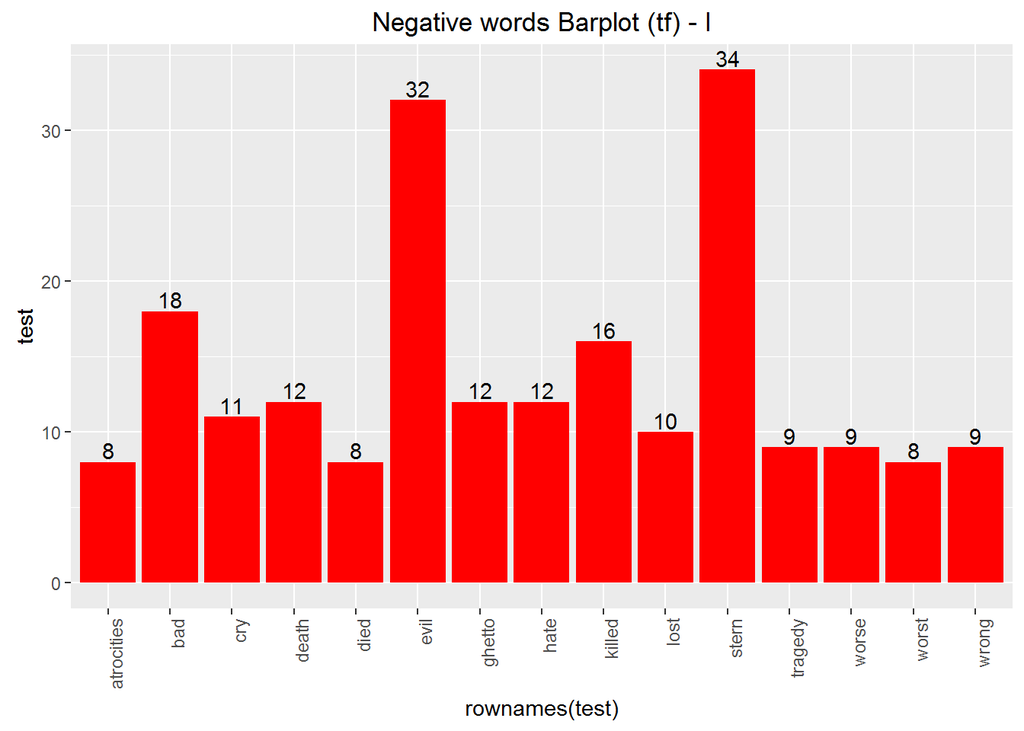

```r
windows()
ggplot(test, aes(x = rownames(test), y = test)) +
  geom_bar(stat = "identity", fill = "red") +
  geom_text(aes(label = test), vjust= -0.20) +
  theme(axis.text.x = element_text(angle = 90, hjust = 1))+
  ggtitle("Negative words Barplot (tf) - I")
```

#### From the Bar Plot, we find words **‘evil’** and **‘stern’** appear frequently. We find words such as ‘death’ and ‘died’. We say that ‘death’ and ‘died’ reflect the same context and so we add the word ‘died’ to the stop words.

```r
stopwords <- c(stopwords,'died')
```

#### Adjacency matrix to plot COG graph

```r
senti.dtm = cbind(pos.tdm, neg.tdm) # COG for sentiment-laden words
senti.adj.mat = as.matrix(t(senti.dtm)) %*% as.matrix(senti.dtm)
diag(senti.adj.mat) = 0
```

#### Distilled COG function

```r
  distill.cog = function(mat1, # input TCM ADJ MAT
                         title, # title for the graph
                         s,    # no. of central nodes
                         k1){  # max no. of connections
    library(igraph)
    a = colSums(mat1) # collect colsums into a vector obj a
    b = order(-a)     # syntax for ordering vector in decr order

    mat2 = mat1[b, b]     # order both rows and columns along vector b

    diag(mat2) =  0

    #go row by row and find top k adjacencies

    wc = NULL

    for (i1 in 1:s){
      thresh1 = mat2[i1,][order(-mat2[i1, ])[k1]]
      mat2[i1, mat2[i1,] < thresh1] = 0
      mat2[i1, mat2[i1,] > 0 ] = 1
      word = names(mat2[i1, mat2[i1,] > 0])
      mat2[(i1+1):nrow(mat2), match(word,colnames(mat2))] = 0
      wc = c(wc,word)
    } # i1 loop ends


    mat3 = mat2[match(wc, colnames(mat2)), match(wc, colnames(mat2))]
    ord = colnames(mat2)[which(!is.na(match(colnames(mat2), colnames(mat3))))]  # removed any NAs from     the list
    mat4 = mat3[match(ord, colnames(mat3)), match(ord, colnames(mat3))]
    graph <- graph.adjacency(mat4, mode = "undirected", weighted=T)    # Create network object
    graph = simplify(graph)
    V(graph)$color[1:s] = "green"
    V(graph)$color[(s+1):length(V(graph))] = "pink"

    graph = delete.vertices(graph, V(graph)[ degree(graph) == 0 ]) # delete singletons

    plot(graph,
         layout = layout.kamada.kawai,
         main = title)

  } # func ends
```

#### COG Graph (tf weighting)

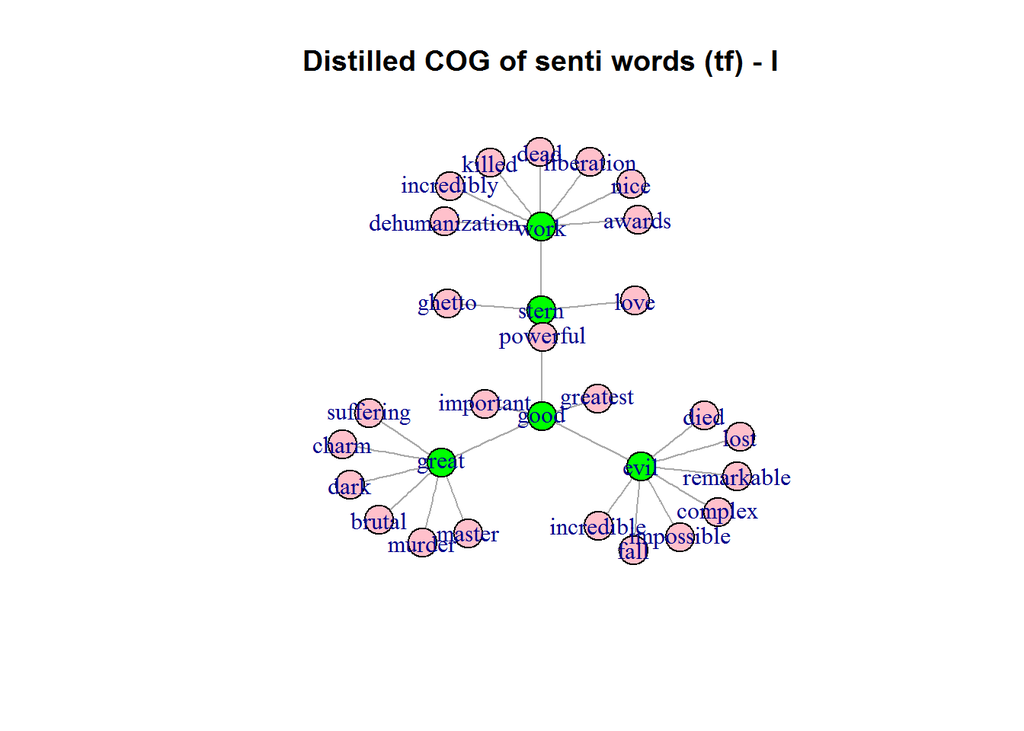

```r
windows()
distill.cog(senti.adj.mat,   # adj mat obj
            'Distilled COG of senti words (tf) - I',# plot title
            5,       # max #central nodes
            5)        # max #connections
```

#### Create DTM TFIDF (term frequency inverse document frequency)

```r
library(textir)
dtm.tfidf = tfidf(dtm, normalize=TRUE)
```

#### Word Cloud and Bar Plot for positive words (tfidf weighting)

```r
pos.tdmtfidf = dtm.tfidf[,which(colnames(dtm.tfidf) %in% positive_words)]
m = as.matrix(pos.tdmtfidf)
v = sort(round(colSums(m),2), decreasing = TRUE)
```

#### Word Cloud

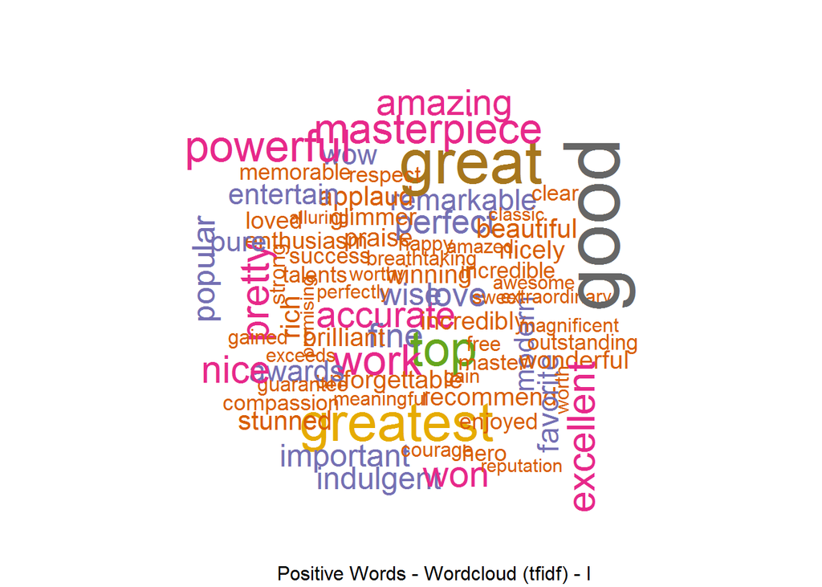

```r
windows() # opens new image window
wordcloud(names(v), v, scale=c(4,0.5),0.01, max.words=75,colors=brewer.pal(8, "Dark2"))
title(sub = "Positive Words - Wordcloud (tfidf) - I")
```

```r
test = round(as.data.frame(v[1:15]),2) # plot barchart for top tokens
```

#### Bar Plot

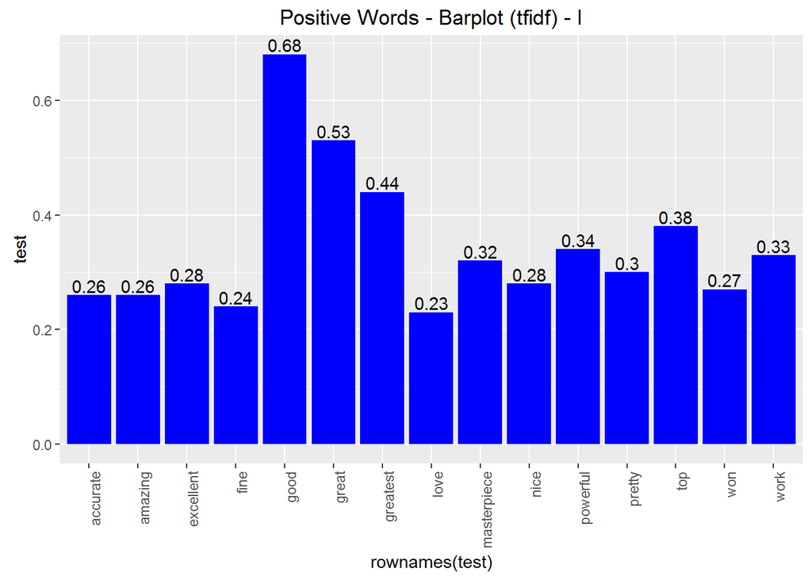

```r
windows() # opens new image window
ggplot(test, aes(x = rownames(test), y = test)) +
  geom_bar(stat = "identity", fill = "blue") +
  geom_text(aes(label = test), vjust= -0.20) +
  theme(axis.text.x = element_text(angle = 90, hjust = 1))+
  ggtitle("Positive Words - Barplot (tfidf) - I")
```

From the Bar Plot, we observe the weights of the common words (‘good’ and ‘great’) has decreased comparing with the tf weights. Some new words have appeared like ‘fine’,‘nice’, and ‘pretty’.

#### Word Cloud and Bar Plot for negative words (tfidf weighting)

```r
neg.tdmtfidf = dtm.tfidf[,which(colnames(dtm.tfidf) %in% negative_words) ]
m = as.matrix(neg.tdmtfidf)
v = sort(round(colSums(m),2), decreasing = TRUE)
```

#### Word Cloud

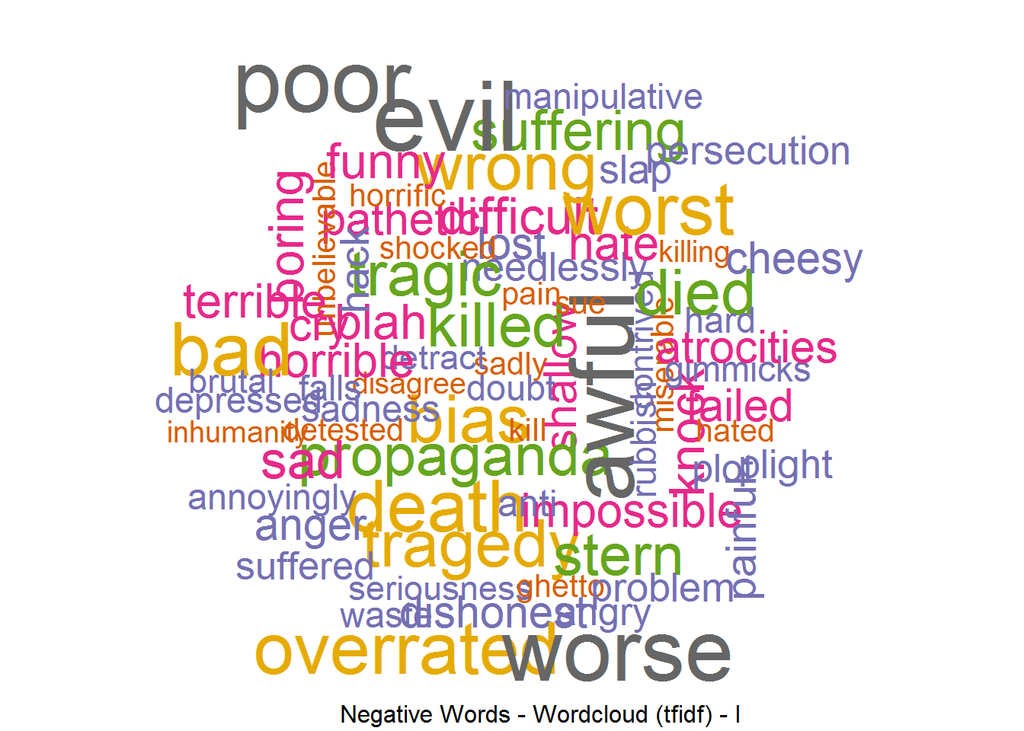

```r
windows()
wordcloud(names(v), v, scale=c(4,0.5),0.01, max.words=75,colors=brewer.pal(8, "Dark2"))
title(sub = "Negative Words - Wordcloud (tfidf) - I")
```

```r
test = round(as.data.frame(v[1:15]),2) # plot barchart for top tokens
```

#### Bar Plot

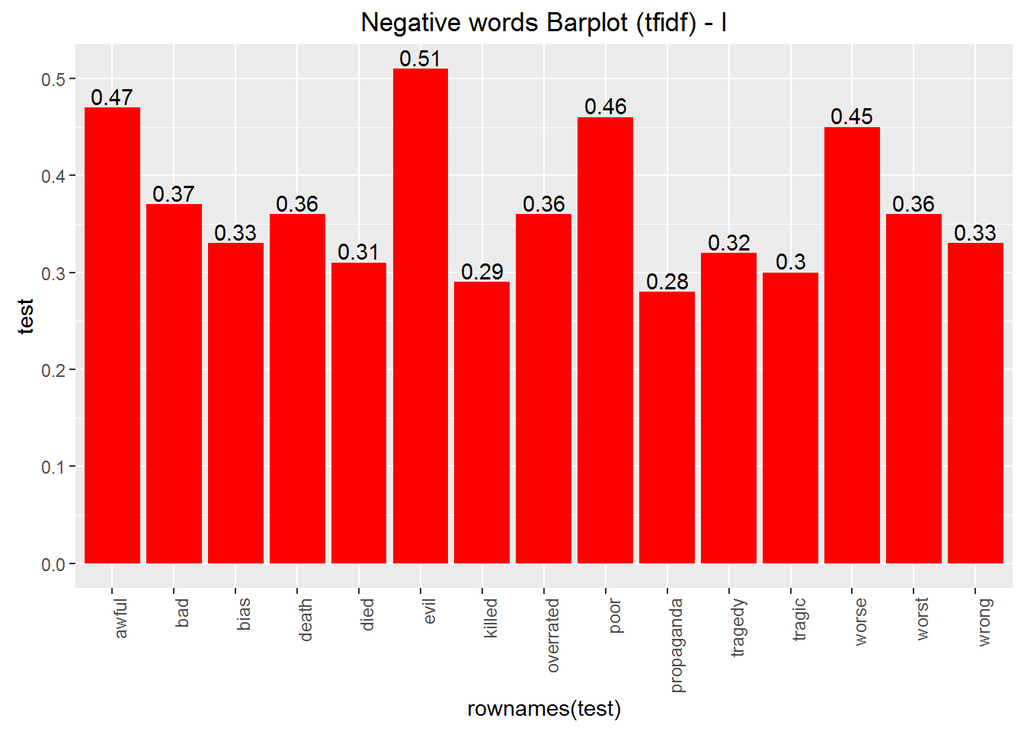

```r
windows()
ggplot(test, aes(x = rownames(test), y = test)) +
  geom_bar(stat = "identity", fill = "red") +
  geom_text(aes(label = test), vjust= -0.20) +
  theme(axis.text.x = element_text(angle = 90, hjust = 1))+
  ggtitle("Negative words Barplot (tfidf) - I")
```

#### From the Bar plot, we find weight of the negative common word ‘evil’ has decreased comparing with its tf weight. New words ‘awful’, ‘bias’, ‘poor’, ‘overrated’ and ‘propaganda’ have appeared. Words ‘death’ and ‘died’ have the same meaning in the given context, we have already added word ‘died’ to the stop words list when we plotted Bar plot for negative words (tf weighting).

#### Negative words ‘worse’ and ‘worst’ appear and they have the same meaning in the given context, hence we add the word ‘worst’ to the stopwords.

```r
stopwords = c(stopwords, 'worst')
```

#### Adjacency matrix (tfidf)

```r
senti.dtmtfidf = cbind(pos.tdmtfidf, neg.tdmtfidf)
adj.mat = t(senti.dtmtfidf) %*% senti.dtmtfidf
diag(adj.mat) = 0
a0 = order(apply(adj.mat, 2, sum), decreasing = T)
adj.mat = as.matrix(adj.mat[a0[1:50], a0[1:50]])
```

#### COG Graph (tfidf)

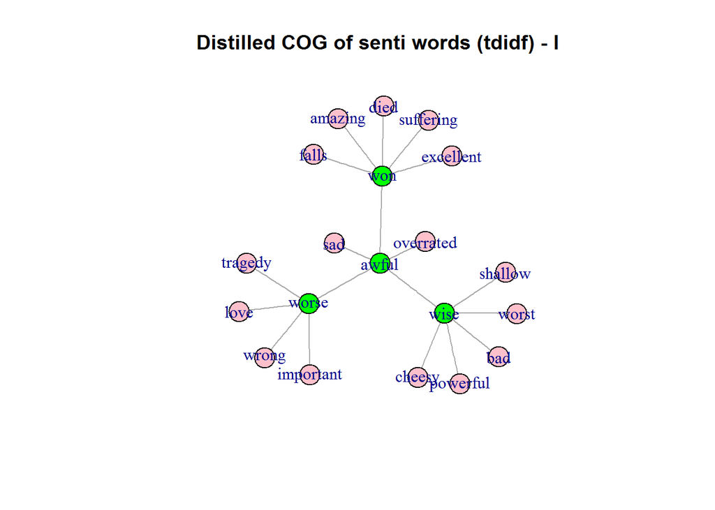

```r
windows()
distill.cog(adj.mat,   # ad mat obj
            'Distilled COG of senti words (tdidf) - I',       # plot title
            5,       # max #central nodes
            5)        # max #connections
```

#### From the COG Graph, we find a central node as word **‘wise’** which doesnot appear in the Bar Plot for positive words (tfidf) - I.

### Iteration

#### We now again do the iteration with the new set of stopwords, and again plot Word Cloud, Bar Plot and COG graph (tf weighting) and (tfidf weighting)

#### Create a Word Cloud and Bar plot for positive words (tf weighting)

#### Word Cloud

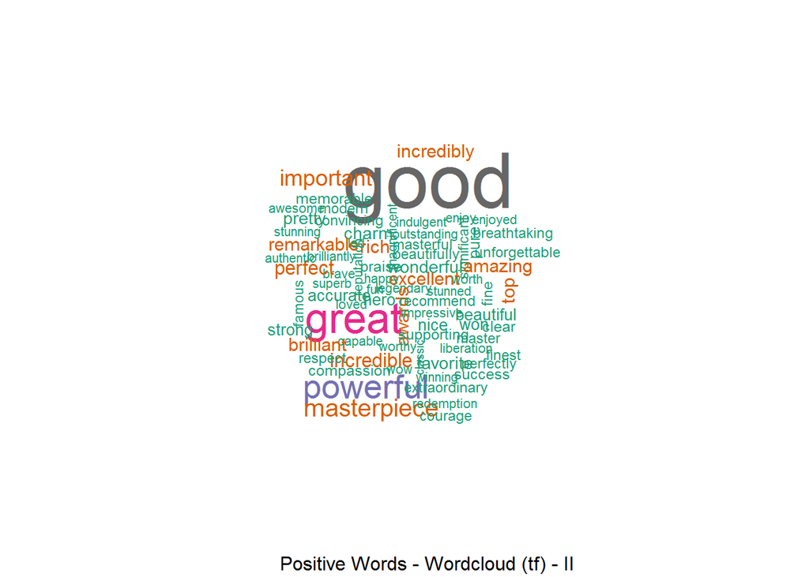

#### Bar plot

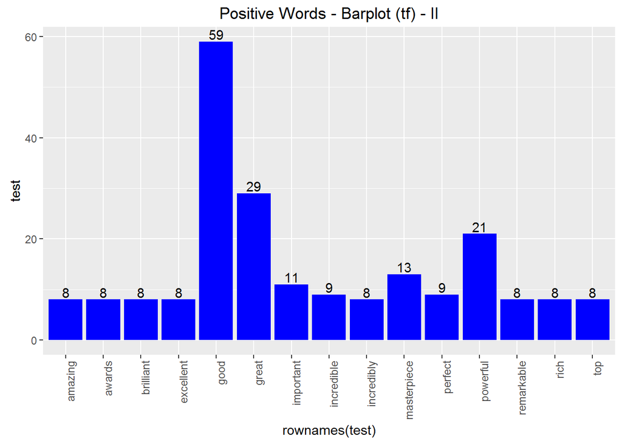

#### Create a Word Cloud and Bar plot for negative words (tf weighting)

#### Word Cloud

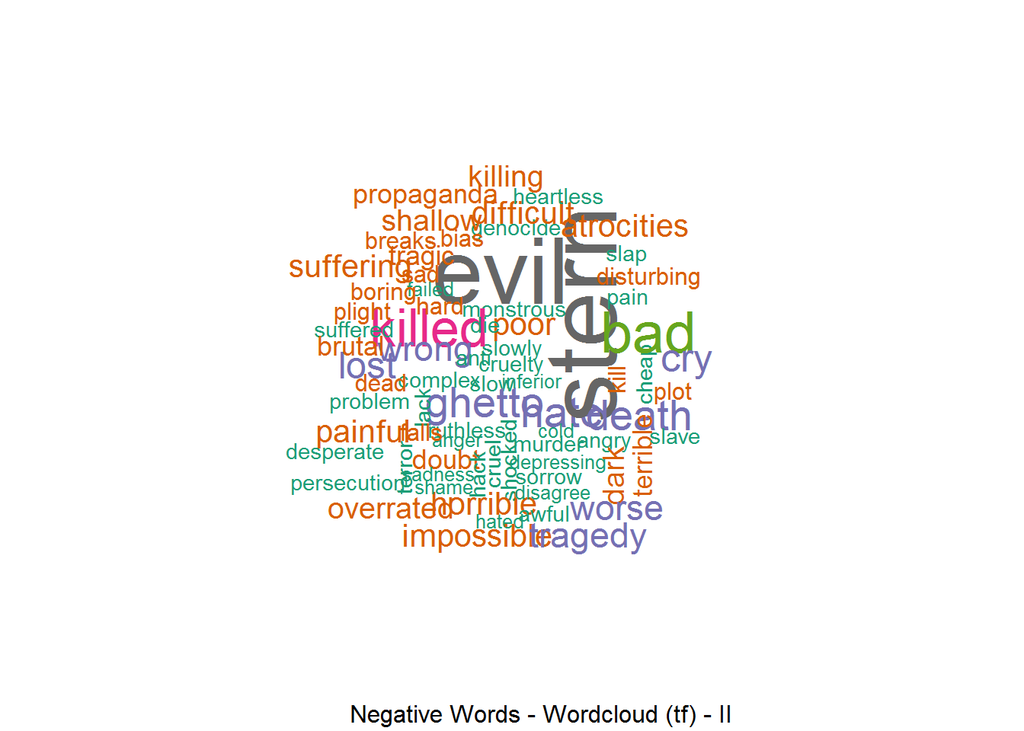

#### Bar Plot

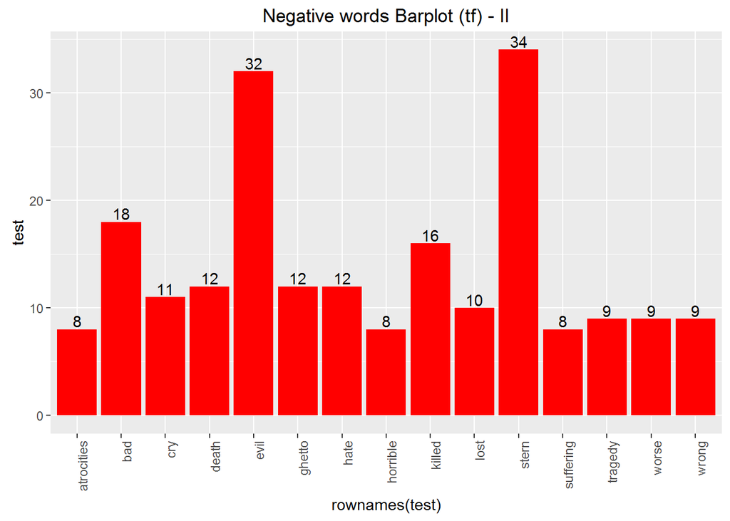

#### COG Graph (tf weighting)

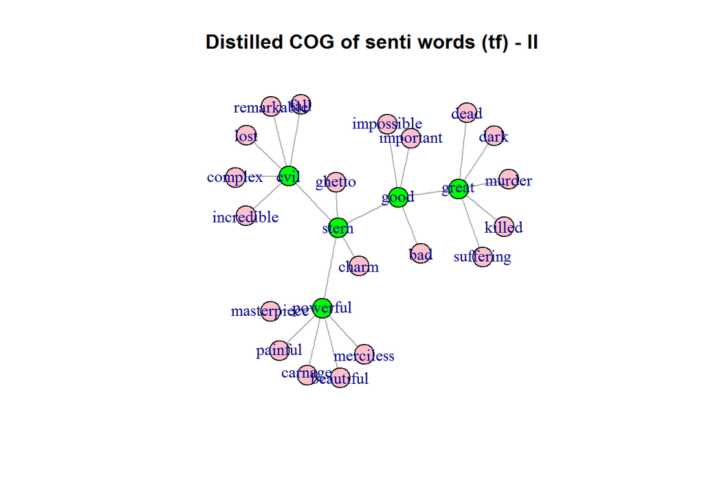

#### Word Cloud and Bar Plot for positive words (tfidf weighting)

#### Word Cloud

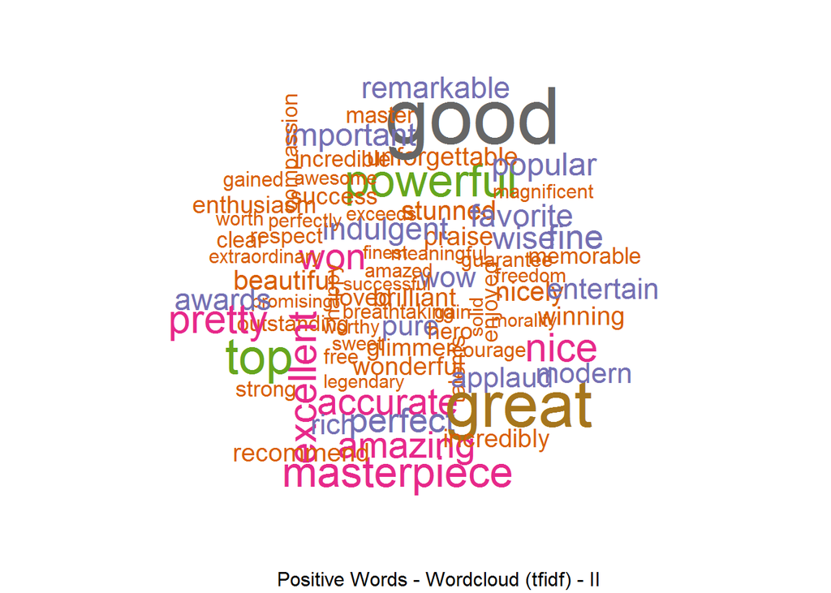

#### Bar Plot

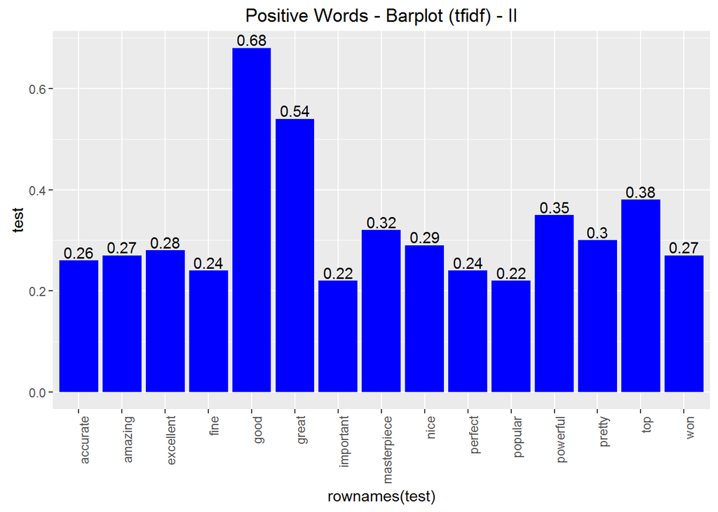

#### Word Cloud and Bar Plot for negative words (tfidf weighting)

#### Word Cloud

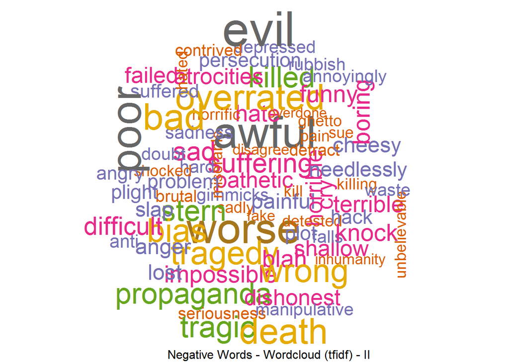

#### Bar Plot

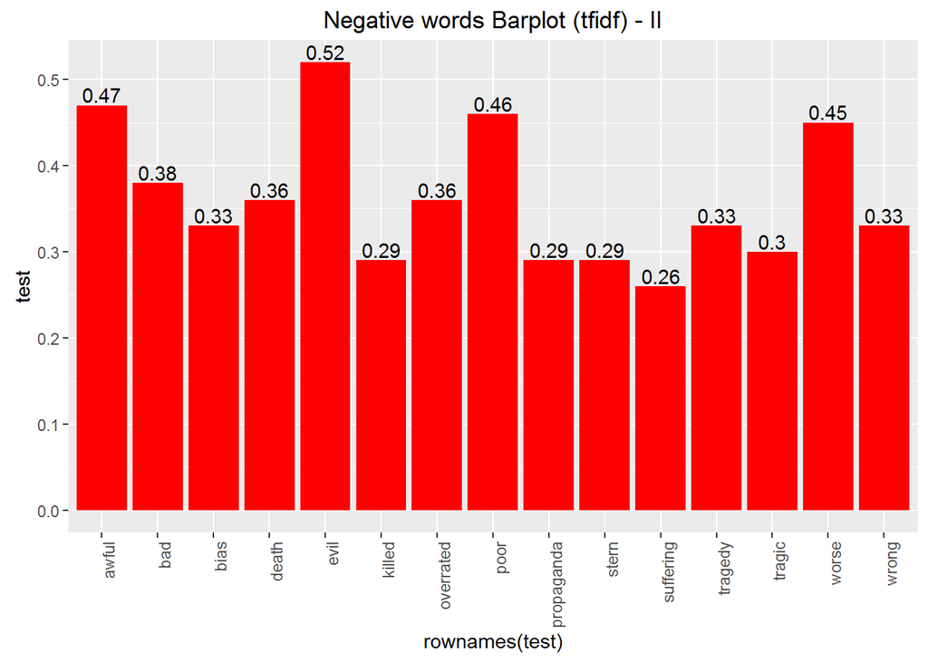

#### COG Graph (tfidf)

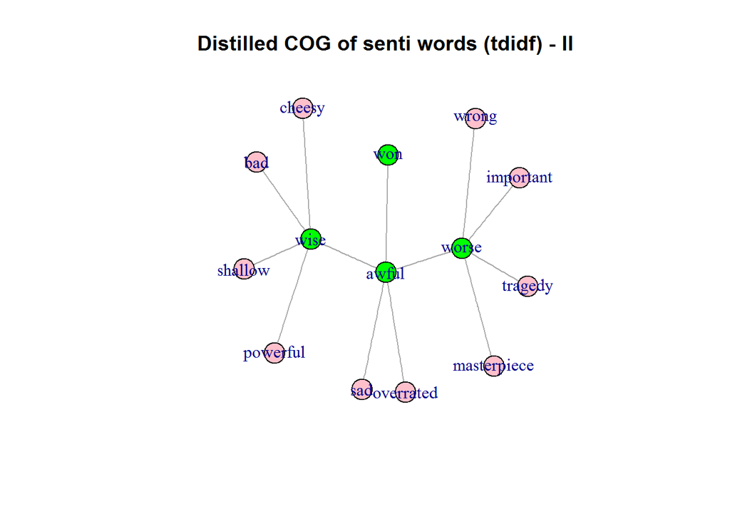

### Analysis

#### After Iteration for dtm tf

1. Positive words - Words such as **‘amazing’, brilliant’, excellent, ‘good’, ‘great’, ‘incredible’,‘masterpiece’ and ‘powerful’** appearing in the reviews point that the movie ‘Schindler’s List’ is worth watching.
2. Negative words - Words such as **‘atrocities’, ‘bad’, ‘cry’, ‘death’, ‘evil’, ‘ghetto’, ‘horrible’,‘stern’,‘tragedy’ and ‘worse’** appearing in the reviews point that the user sentiments are negative and they were unhappy after watching the movie.
3. From COG, we find the central nodes have both the positive (‘good’,‘powewrful’ and ‘great’) and negative(‘stern’ and ‘evil’) words. We need to look into polarity of the reviews to get an overall idea about the reviews.

#### After Iteration for dtm tfidf

1. Positive words - Words such as **‘accurate’,‘amazing’, ‘excellent’, ‘good’, ‘great’, ‘masterpiece’, ‘fine’, ‘nice’,‘powerful’and ’won’** appearing in the reviews point that the movie ‘Schindler’s List’ is worth watching.
2. Negative words - Words such as **‘awful’, ‘bad’, ‘death’, ‘evil’, ‘overrated’, ‘poor’, ‘tragic’ and ‘worse’** appearing in the reviews point that the user sentiments are negative and they were unhappy after watching the movie.
3. From COG, we find the central nodes have both the positive(‘won’ and ‘wise’) and negative(‘awful’ and ‘worse’) words. We need to look into polarity of the reviews to get an overall idea about the reviews.

### Sentiment Polarity for movie Schindler’s List

We find correlation between the **polarity** for the reviews and the **ratings** provided for the reviews.Total Reviews are 100.

#### Positive reviews collected

```r
pr <- data$ratings>9
prc <- length(data$ratings[pr])
prc
```

```
## [1] 50
```

#### Negative reviews collected

```r
(100 - prc)
```

```
## [1] 50
```

#### Total positive words found in the reviews

```r
length(positive_words)
```

```
## [1] 306
```

#### Total negative words found in the reviews

```r
length(negative_words)
```

```
## [1] 493
```

#### We observe negative words (493) are more in the reviews than the positive words (306).

#### Polarity vector

```r
pol$all$polarity
```

```
##   [1]  0.35494260  0.00000000  0.93831486  0.18569534  0.10787198
##   [6]  1.02419018 -0.29675382 -0.52522573 -1.67381213  0.50387103
##  [11] -0.67419986  0.19245009 -0.38490018  0.36115756 -0.68348613
##  [16]  0.00000000 -0.60302269  0.00000000  0.07559289 -1.26054176
##  [21] -0.17149859  0.65232807  0.33686077 -0.33541020 -0.30151134
##  [26] -0.39391930 -0.14213381 -1.41171569 -0.94300544  0.24567691
##  [31] -0.98386991 -0.28347335 -0.28538708  0.40451992 -1.42373699
##  [36] -1.17901357 -1.64543911  0.11043153 -1.54941591 -0.50395263
##  [41]  0.14744196 -0.77302068  0.07627701 -0.22857143  0.29329423
##  [46] -0.69368798 -1.29282128  0.82679835 -0.48019604  0.51214752
##  [51] -1.06841445 -1.39427400 -0.22677868  0.35132403 -0.74535599
##  [56]  0.18856181 -0.07427814 -0.96152395 -0.26186147  0.77459667
##  [61] -0.16873230 -0.01576221  0.41791562 -0.18983160  0.44426598
##  [66] -0.09922779  0.31684721 -0.73301667  0.29052007  0.01951800
##  [71]  0.82623645 -1.35325058 -0.16963779 -0.45883147 -0.41039134
##  [76]  0.17149859 -0.40451992 -0.26261287 -0.12500000 -0.89442719
##  [81]  1.01823858  0.51961524 -0.40567404  1.08012345 -0.32929278
##  [86]  0.98149546  0.45749571  0.53452248 -0.12403473  0.52387878
##  [91] -0.36514837 -0.51722619 -2.08699678 -0.80138769 -0.16903085
##  [96] -0.54679343 -0.75615125 -0.34743961 -0.62554324 -0.14948702
```

#### We find the most positive review and most negative review.

#### Most positive Review

```r
max(pol$all$polarity)
```

```
## [1] 1.080123
```

#### The most positive review has a polarity of **1.080123**. The review is as follows:

```r
ind = which(round(pol$all$polarity,6) == 1.080123)
data$reviews[ind]
```

```
## [1] " This movie is one of the greatest movie that I have ever watched. The director is one of my favorite. It talk about a man who has no work but used his work in saving the Jews. The director has used different colors and different shots. it also shows us and tries to remember us the holocaust…
```

#### Most negative Review

```r
min(pol$all$polarity)
```

```
## [1] -2.086997
```

#### The most negative review has a polarity of **-2.086997**. The review is as follows:

```r
ind = which(round(pol$all$polarity,6) == -2.086997)
data$reviews[ind]
```

```
## [1] " This is one of the worst movies i have ever seen, and it made me very angry. This movie is so one sided and dishonest, so terribly sentimental(in the wrong way) and so flawed and biased that falls immediately into the category of deliberate immorality, obscenity and perversion.I think Spiel…
```

#### Ratings vector

```r
data$ratings
```

```
##   [1] 10 10 10 10 10 10 10 10 10 10  1  1  1  1  1  1  1  1  1  1 10 10 10
##  [24] 10 10 10 10 10 10 10  1  1  1  1  1  1  1  1  1  1 10 10 10 10 10 10
##  [47] 10 10 10 10  1  1  1  1  1  1  1  1  1  1 10 10 10 10 10 10 10 10 10
##  [70] 10  1  1  1  1  1  1  1  1  1  1 10 10 10 10 10 10 10 10 10 10  1  1
##  [93]  1  1  1  1  1  1  2  2
```

#### We find correlation between polarity vector and ratings vector.

```r
cor(pol$all$polarity, data$ratings)
```

```
## [1] 0.3667409
```

#### We observe that there is a **moderate positive correlation (0.3667409)** between polarity of reviews and ratings given by the users for the reviews. We can predict that as ratings increase the polarity for that review increases.

#### Positive Words vs. Negative words

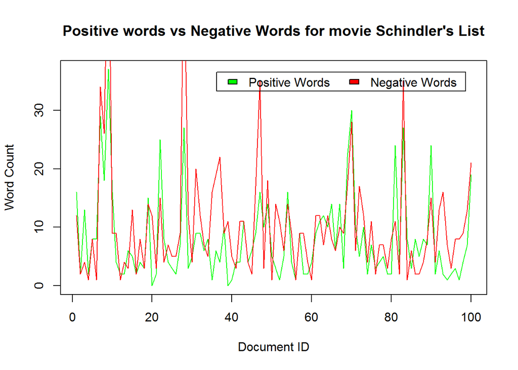

### Sentiment Polarity Plot for Schindler’s List

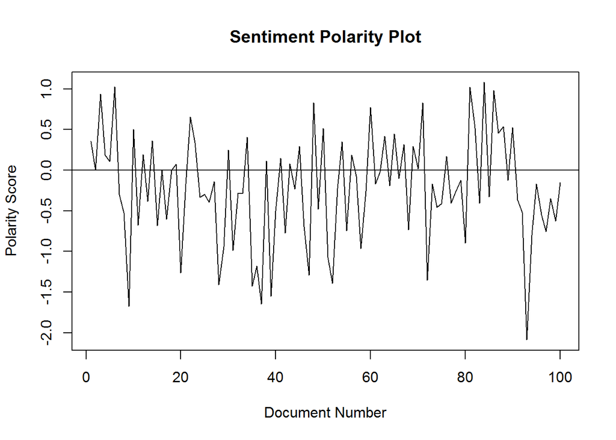

#### We observe the sentiment for Schindler’s list mostly appears to be negative below the zero line.

### Recommendations for making a Sequel

#### 1. Frequently appearing positive words - The users have used the words like ‘amazing’, ‘excellent’,‘good’,‘great’ and ‘masterpiece’ in their reviews pointing that they liked the movie very much. All positive reviews have been rated with rating ‘10/10’. Words like ‘powerful’ and ‘remarkable’ tell us that movie has a very **powerful message** which gets to the viewer very clearly and the user really likes that giving a rating of ‘10/10’. Words like ‘fine’, ‘nice’ and ‘pretty’ have appeared in the reviews reflecting the beauty of the movie .

#### 2. The sentiment for the movie mostly appears to be negative below the zero line. This means that are several negative aspects which should be avoided when making a sequel. Frequently used negative words - ‘atrocities’, ‘evil’, ‘ghetto’,‘horibble’ and ‘worse’ reflect negative sentiments of the users. Words such as ‘awful’, ‘overrated’, ‘poor’ and ‘propaganda’ reflect negative sentiments.

#### 3. We analyze the most positive review - The user likes saving of the Jew people and remembrance of the holocaust day. The user likes the star cast - Liam Neeson and Ben Kingsley. The user feels the incidents shown in the movie are true. The user likes different colors used in the movie.

#### 4. We analyze the most negative review - The user thinks that the movie is flawed and biased towards Germans and is impossible to watch. The movie has deliberate immorality, obscenity, perversions and pornograhic dimensions.

### 5. Overall

### **Attributes/Aspects to be retained** - Powerful message, Star cast - Liam Neeson and Ben Kingsley, True incidents, Different colors.

### **Attributes/Aspects to be changed** - Dont show or reduce evil, horrible, immoral, obscene and pornographic incidents. The incidents shown should not reflect biasness towards a community or a group of people and create a propaganda about it.

##### 1. Index of element

###### https://ubuntuforums.org/showthread.php?t=939573

##### 2.tf-idf

###### https://en.wikipedia.org/wiki/Tf%E2%80%93idf